# Experiment Report

This report presents the analysis for **lr_with_h2**: Using all features with an LinearRegression model.

Tue May 24 11:08:55 2016

## Description of the data

### Responses excluded due to non-numeric feature values or scores

#### Training set

Total number of excluded responses: 0 (0.0% of the original 500)

#### Evaluation set

Total number of excluded responses: 0 (0.0% of the original 200)

The rest of this report is based only on the responses used to build and train the model.

### Composition of the training and evaluation sets

| partition | responses |
| --- | --- |
| Training | 500 |
| Evaluation | 200 |
| Overlapping | 200 |
| Total | 500 |

Total number of double scored responses used: 200 (zeros excluded)

## Overall descriptive feature statistics

These values are reported before transformations.

[output not shown]

### Prevalence of recoded cases

This sections shows the number and percentage of cases truncated to mean +/- 4 SD for each feature.

[figure not shown]

### Feature value distribution

|  | 1% | 5% | 25% | 50% | 75% | 95% | 99% | IQR | Mild outliers | Extreme outliers |
| --- | --- | --- | --- | --- | --- | --- | --- | --- | --- | --- |
| FEATURE1 | 3.245 | 4.442 | 4.949 | 5.234 | 5.500 | 6.083 | 6.457 | 0.551 | 18 | 5 |
| FEATURE2 | -0.245 | -0.146 | -0.115 | -0.095 | -0.079 | -0.061 | -0.058 | 0.035 | 5 | 5 |
| FEATURE3 | -0.408 | -0.316 | -0.232 | -0.189 | -0.121 | -0.070 | -0.060 | 0.110 | 5 | 0 |
| FEATURE4 | -0.622 | -0.452 | -0.302 | -0.201 | -0.001 | 0.001 | 0.002 | 0.301 | 0 | 0 |
| FEATURE5 | -0.190 | -0.161 | -0.125 | -0.096 | -0.072 | -0.001 | 0.001 | 0.053 | 0 | 0 |
| FEATURE6 | 3.288 | 3.896 | 4.281 | 4.489 | 4.631 | 4.881 | 5.061 | 0.351 | 8 | 2 |
| FEATURE7 | 1.000 | 2.000 | 6.000 | 10.000 | 16.000 | 19.000 | 20.000 | 10.000 | 0 | 0 |
| FEATURE8 | -13385.395 | -12497.212 | -10498.892 | -8566.848 | -6375.795 | -4419.712 | -3711.225 | 4123.097 | 0 | 0 |

## Feature Distributions and Inter-feature Correlations

### Training set distributions

The following plot shows the distributions of the feature values in the training set, after transformation (if applicable), truncation and standardization. The line shows the kernel density estimate. The human score (`sc1`) is also included.

Response length (`length`) is included if you specified `length_column` in the config file, unless the column had missing values or a standard deviation <= 0.

[figure not shown]

### Inter-feature correlations

The following table shows the Pearson correlations between all the training features after transformation (if applicable), truncation and standardization. The human score (`sc1`) is also included.

Response length (`length`) is included if you specified `length_column` in the config file, unless the column had missing values or a standard deviation <= 0.

The following values are highlighted in red:

- inter-feature correlations above 0.7, and
- `sc1`-feature correlations lower than 0.1 or higher than 0.7

|  | sc1 | FEATURE1 | FEATURE2 | FEATURE3 | FEATURE4 | FEATURE5 | FEATURE6 | FEATURE7 | FEATURE8 |
| --- | --- | --- | --- | --- | --- | --- | --- | --- | --- |
| sc1 | 1.000 | 0.576 | 0.321 | 0.510 | 0.488 | 0.330 | 0.252 | -0.069 | -0.105 |
| FEATURE1 | 0.576 | 1.000 | 0.236 | 0.408 | 0.464 | 0.218 | -0.080 | -0.043 | -0.020 |
| FEATURE2 | 0.321 | 0.236 | 1.000 | 0.370 | 0.316 | 0.397 | 0.200 | -0.005 | -0.077 |
| FEATURE3 | 0.510 | 0.408 | 0.370 | 1.000 | 0.341 | 0.367 | 0.287 | 0.025 | -0.047 |
| FEATURE4 | 0.488 | 0.464 | 0.316 | 0.341 | 1.000 | 0.325 | 0.259 | -0.016 | -0.091 |
| FEATURE5 | 0.330 | 0.218 | 0.397 | 0.367 | 0.325 | 1.000 | 0.267 | -0.006 | -0.083 |
| FEATURE6 | 0.252 | -0.080 | 0.200 | 0.287 | 0.259 | 0.267 | 1.000 | 0.023 | -0.034 |
| FEATURE7 | -0.069 | -0.043 | -0.005 | 0.025 | -0.016 | -0.006 | 0.023 | 1.000 | 0.035 |
| FEATURE8 | -0.105 | -0.020 | -0.077 | -0.047 | -0.091 | -0.083 | -0.034 | 0.035 | 1.000 |

### Marginal and partial correlations

The plot below shows correlations between truncated and standardized values of each feature against human score. The first bar (`Marginal`) in each case shows Pearson's correlation. The second bar (`Partial - all`) shows partial correlations after controlling for all other variables. If you specified `length_column` in the config file, a third bar (`Partial - length`) will show partial correlations of each feature against the human score after controlling for length.

[figure not shown]

Consistency

Human-human agreement

This table shows the human-human agreement on the double-scored evaluation data. The following are highlighted in red:

- Exact agreement (`exact_agr`) < 50%

- Adjacent agreement (`adj_agr`) < 95%

- Quadratic weighted kappa (`wtkappa`) < 0.7

- Pearson correlation (`corr`) < 0.7

| N | h1_mean | h1_sd | h1_min | h1_max | h2_mean | h2_sd | h2_min | h2_max | corr | wtkappa | kappa | exact_agr | adj_agr | SMD |
| --- | --- | --- | --- | --- | --- | --- | --- | --- | --- | --- | --- | --- | --- | --- |
| 200.000 | 3.500 | 0.924 | 1.000 | 5.000 | 3.425 | 0.894 | 1.000 | 5.000 | 0.837 | 0.833 | 0.591 | 72.500 | 100.000 | -0.083 |

Degradation

The next table shows the degradation in the evaluation metrics (`diff`) when comparing the machine (`H-M`) to a second human (`H-H`). A positive degradation value indicates better human-machine performance. Note that the human-machine agreement is computed on the full dataset (to get a reliable estimate) whereas the human-human agreement is computed on the subset of responses that were double-scored.

The following degradation values are highlighted in red:

- `corr` < -0.1

- `wtkappa` < -0.1

|  |  | corr | kappa | wtkappa | exact_agr | adj_agr | SMD |
| --- | --- | --- | --- | --- | --- | --- | --- |
| raw | H-H | 0.837 | 0.591 | 0.833 | 72.500 | 100.000 | -0.083 |
|  | H-M | 0.780 | 0.386 | 0.707 | 0.000 | 90.000 | -0.010 |
|  | diff | -0.056 | -0.205 | -0.126 | -72.500 | -10.000 | 0.072 |
| raw_trim | H-H | 0.837 | 0.591 | 0.833 | 72.500 | 100.000 | -0.083 |
|  | H-M | 0.780 | 0.386 | 0.707 | 0.000 | 90.000 | -0.010 |
|  | diff | -0.056 | -0.205 | -0.126 | -72.500 | -10.000 | 0.072 |
| raw_trim_round | H-H | 0.837 | 0.591 | 0.833 | 72.500 | 100.000 | -0.083 |
|  | H-M | 0.733 | 0.386 | 0.707 | 60.500 | 100.000 | -0.018 |
|  | diff | -0.104 | -0.205 | -0.126 | -12.000 | 0.000 | 0.064 |
| scale | H-H | 0.837 | 0.591 | 0.833 | 72.500 | 100.000 | -0.083 |
|  | H-M | 0.780 | 0.469 | 0.782 | 0.000 | 84.500 | 0.023 |
|  | diff | -0.056 | -0.122 | -0.051 | -72.500 | -15.500 | 0.106 |
| scale_trim | H-H | 0.837 | 0.591 | 0.833 | 72.500 | 100.000 | -0.083 |
|  | H-M | 0.780 | 0.469 | 0.782 | 0.000 | 84.500 | 0.023 |
|  | diff | -0.056 | -0.122 | -0.051 | -72.500 | -15.500 | 0.106 |
| scale_trim_round | H-H | 0.837 | 0.591 | 0.833 | 72.500 | 100.000 | -0.083 |
|  | H-M | 0.783 | 0.469 | 0.782 | 64.000 | 99.000 | -0.011 |
|  | diff | -0.054 | -0.122 | -0.051 | -8.500 | -1.000 | 0.072 |

## Model

Model used: **LinearRegression**

Number of features in model: **8**

Model summary

```
                            OLS Regression Results
==============================================================================
Dep. Variable:                    sc1   R-squared:                       0.497
Model:                            OLS   Adj. R-squared:                  0.489
Method:                 Least Squares   F-statistic:                     60.66
Date:                Tue, 24 May 2016   Prob (F-statistic):           1.66e-68
Time:                        11:08:53   Log-Likelihood:                -435.13
No. Observations:                 500   AIC:                             888.3
Df Residuals:                     491   BIC:                             926.2
Df Model:                           8
Covariance Type:            nonrobust
==============================================================================
                 coef    std err          t      P>|t|      [95.0% Conf. Int.]
------------------------------------------------------------------------------
const          3.4200      0.026    131.176      0.000         3.369     3.471
FEATURE1       0.3361      0.033     10.269      0.000         0.272     0.400
FEATURE2       0.0345      0.030      1.153      0.249        -0.024     0.093
FEATURE3       0.1702      0.032      5.314      0.000         0.107     0.233
FEATURE4       0.1195      0.032      3.720      0.000         0.056     0.183
FEATURE5       0.0402      0.030      1.332      0.184        -0.019     0.100
FEATURE6       0.1349      0.030      4.553      0.000         0.077     0.193
FEATURE7      -0.0454      0.026     -1.733      0.084        -0.097     0.006
FEATURE8      -0.0483      0.026     -1.836      0.067        -0.100     0.003
==============================================================================
Omnibus:                        9.067   Durbin-Watson:                   2.317
Prob(Omnibus):                  0.011   Jarque-Bera (JB):               12.045
Skew:                          -0.170   Prob(JB):                      0.00242
Kurtosis:                       3.681   Cond. No.                         2.61
==============================================================================

Warnings:
[1] Standard Errors assume that the covariance matrix of the errors is correctly specified.
```

### Standardized and Relative Regression Coefficients (Betas)

The relative coefficients are intended to show relative contribution of different feature and their primary purpose is to indentify whether one of the features has an unproportionate effect over the final score. They are computed as standardized/(sum of absolute values of standardized coefficients).

Negative standardized coefficients are highlighted in red.

**Note**: if the model contains negative coefficients, relative values will not sum up to one and their interpretation is generally questionable.

| feature | standardized | relative |
| --- | --- | --- |
| FEATURE1 | 0.412 | 0.362 |
| FEATURE2 | 0.042 | 0.037 |
| FEATURE3 | 0.209 | 0.183 |
| FEATURE4 | 0.147 | 0.129 |
| FEATURE5 | 0.049 | 0.043 |
| FEATURE6 | 0.165 | 0.145 |
| FEATURE7 | -0.056 | -0.049 |
| FEATURE8 | -0.059 | -0.052 |

Here are the same values, shown graphically.

[figure not shown]

Model diagnostics

These are standard plots for model diagnostics for the main model. All information is computed based on the training set.

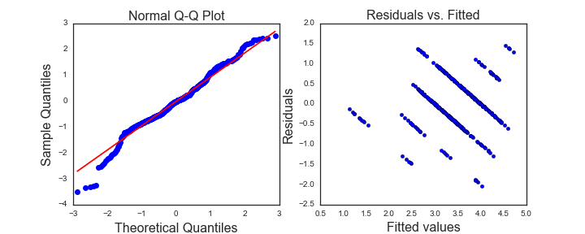

## Evaluation results

### Association statistics

The table shows the standard association metrics between human scores and different types of machine scores. These results are computed on the evaluation set. `Trim` (`bound`) scores are truncated to [min-0.4998, max+.4998]. `Trim-round` scores are computed by first truncating and then rounding the predicted score. Scaled scores are computed by re-scaling the predicted scores using mean and standard deviation of human scores as observed on the training data and mean and standard deviation of machine scores as predicted for the training set. Note that for the computation of kappas scores are always rounded.

SMD values lower then -0.15 or higher than 0.15 are highlighted in red.

|  | N | h_mean | h_sd | h_min | h_max | sys_mean | sys_sd | sys_min | sys_max | corr | wtkappa | kappa | exact_agr | adj_agr | SMD |
| --- | --- | --- | --- | --- | --- | --- | --- | --- | --- | --- | --- | --- | --- | --- | --- |
| raw | 200.000 | 3.500 | 0.924 | 1.000 | 5.000 | 3.492 | 0.666 | 1.596 | 4.701 | 0.780 | 0.707 | 0.386 | 0.000 | 90.000 | -0.010 |
| raw_trim | 200.000 | 3.500 | 0.924 | 1.000 | 5.000 | 3.492 | 0.666 | 1.596 | 4.701 | 0.780 | 0.707 | 0.386 | 0.000 | 90.000 | -0.010 |
| raw_trim_round | 200.000 | 3.500 | 0.924 | 1.000 | 5.000 | 3.485 | 0.709 | 2.000 | 5.000 | 0.733 | 0.707 | 0.386 | 60.500 | 100.000 | -0.018 |
| scale | 200.000 | 3.500 | 0.924 | 1.000 | 5.000 | 3.522 | 0.945 | 0.832 | 5.237 | 0.780 | 0.782 | 0.469 | 0.000 | 84.500 | 0.023 |
| scale_trim | 200.000 | 3.500 | 0.924 | 1.000 | 5.000 | 3.522 | 0.945 | 0.832 | 5.237 | 0.780 | 0.782 | 0.469 | 0.000 | 84.500 | 0.023 |
| scale_trim_round | 200.000 | 3.500 | 0.924 | 1.000 | 5.000 | 3.490 | 0.972 | 1.000 | 5.000 | 0.783 | 0.782 | 0.469 | 64.000 | 99.000 | -0.011 |

### Confusion Matrix

Confusion matrix using scaled trimmed rounded scores (rows=system, columns=human).

|  | 1 | 2 | 3 | 4 | 5 |
| --- | --- | --- | --- | --- | --- |
| 1 | 3 | 8 | 0 | 0 | 0 |
| 2 | 2 | 12 | 0 | 0 | 0 |
| 3 | 0 | 3 | 39 | 21 | 0 |
| 4 | 0 | 2 | 16 | 63 | 9 |
| 5 | 0 | 0 | 0 | 11 | 11 |

### Distribution of human and machine scores

The histogram and the table below show the distibution of human scores and scaled trimmed rounded machine scores (as % of all responses). Differences in the table between human and machine distributions larger than 5 percentage points are highlighted in red.

[figure not shown]

| score | human | sys_scale | difference |
| --- | --- | --- | --- |
| 1.0 | 2.5 | 5.5 | 3.000 |
| 2.0 | 12.5 | 7.0 | -5.500 |
| 3.0 | 27.5 | 31.5 | 4.000 |
| 4.0 | 47.5 | 45.0 | -2.500 |
| 5.0 | 10.0 | 11.0 | 1.000 |

## Principal component analysis

PCA using scaled data and singular value decomposition. This is computed using processed features after the truncation of outliers and other transformations specified in feature config file.

|  | PC1 | PC2 | PC3 | PC4 | PC5 | PC6 | PC7 | PC8 |
| --- | --- | --- | --- | --- | --- | --- | --- | --- |
| FEATURE1 | 0.375 | -0.618 | 0.169 | 0.102 | -0.160 | 0.078 | -0.063 | -0.635 |
| FEATURE2 | 0.418 | 0.096 | -0.033 | -0.021 | 0.603 | -0.129 | 0.653 | -0.091 |
| FEATURE3 | 0.463 | -0.006 | 0.133 | -0.024 | -0.034 | 0.767 | -0.048 | 0.419 |
| FEATURE4 | 0.450 | -0.170 | 0.020 | 0.040 | -0.465 | -0.550 | 0.127 | 0.481 |
| FEATURE5 | 0.426 | 0.200 | -0.063 | -0.064 | 0.403 | -0.258 | -0.735 | -0.031 |
| FEATURE6 | 0.277 | 0.662 | -0.066 | -0.251 | -0.475 | 0.058 | 0.105 | -0.423 |
| FEATURE7 | -0.009 | 0.315 | 0.658 | 0.680 | 0.004 | -0.067 | -0.008 | -0.035 |
| FEATURE8 | -0.097 | -0.055 | 0.715 | -0.677 | 0.073 | -0.108 | 0.002 | 0.045 |

|  | PC1 | PC2 | PC3 | PC4 | PC5 | PC6 | PC7 | PC8 |
| --- | --- | --- | --- | --- | --- | --- | --- | --- |
| Cumulative percentage of variance | 0.315 | 0.456 | 0.585 | 0.703 | 0.800 | 0.879 | 0.954 | 1.000 |
| Eigenvalues | 2.512 | 1.128 | 1.028 | 0.947 | 0.769 | 0.637 | 0.595 | 0.369 |
| Percentage of variance | 0.315 | 0.141 | 0.129 | 0.119 | 0.096 | 0.080 | 0.075 | 0.046 |

[figure not shown]

## System information

```
This report was generated using rsmtool v4.6.0 on a 64bit computer running Mac OS X.
```

### Python packages

[output not shown]